# Data Exploration and Analytical Decisions

Luke J. Eberhart-Phillips and Martin Bulla

2020-08-12 14:10:45

## Libraries

```r
library(tidyverse)
library(lme4)
library(standardize)
library(kableExtra)
library(ggpubr)
library(here)
library(effects)
library(performance)
library(GGally)
```

## Plotting Theme

```r
# define the plotting theme to be used in subsequent ggplots
luke_theme <-
  theme_bw() +
  theme(
    text = element_text(family = "Franklin Gothic Book"),
    legend.title = element_text(size = 10),
    legend.text = element_text(size = 8),
    axis.title.x = element_text(size = 10),
    axis.text.x  = element_text(size = 8),
    axis.title.y = element_text(size = 10),
    axis.text.y = element_text(size = 8),
    panel.grid.major = element_blank(),
    panel.grid.minor = element_blank(),
    axis.ticks = element_line(size = 0.5, colour = "grey40"),
    axis.ticks.length = unit(0.2, "cm"),
    panel.border = element_rect(linetype = "solid", colour = "grey")
  )

# set the ggplotting theme
theme_set(luke_theme)
```

## Data Import and tidy

```r
BT_data <- read.csv(here("Data/blue_tit_data.csv"), stringsAsFactors = FALSE)
```

```r
BT_data_tidy <-
  BT_data %>%
  # select variables of interest
  select(chick_ring_number, hatch_year, hatch_nest_breed_ID, rear_nest_breed_ID, rear_area, hatch_mom_Ring,
         genetic_dad_ring_.WP_or_EP., hatch_nest_OH, rear_nest_OH, d0_hatch_nest_brood_size, rear_d0_rear_nest_brood_size,
         rear_nest_trt, net_rearing_manipulation, rear_Cs_at_start_of_rearing, d14_rear_nest_brood_size,
         day_14_tarsus_length, day_14_weight, day14_measurer, chick_sex_molec, number_chicks_fledged_from_rear_nest) %>%
  # rename the genetic dad vaiable
  rename(genetic_dad_ring = genetic_dad_ring_.WP_or_EP.,
         d0_rear_nest_brood_size = rear_d0_rear_nest_brood_size) %>%
  # replace all "." with NA in factor variables
  mutate(chick_sex_molec = as.factor(ifelse(chick_sex_molec == ".", NA,
                                ifelse(chick_sex_molec == "1", "Female", "Male"))),
         chick_BMI = day_14_weight/(day_14_tarsus_length^2)) %>%
  mutate_at(c("hatch_year", "hatch_nest_breed_ID", "rear_nest_breed_ID",
              "day14_measurer", "rear_nest_trt", "hatch_mom_Ring",
              "genetic_dad_ring", "chick_ring_number", "rear_area"),
            as.factor) %>%
  mutate_if(is.factor, list(~na_if(., "."))) %>%
  mutate_at(c("net_rearing_manipulation", "rear_Cs_at_start_of_rearing", "d0_hatch_nest_brood_size",
              "d0_rear_nest_brood_size", "number_chicks_fledged_from_rear_nest"),
            as.numeric) %>%
  # re-name the treatment groups
  mutate(rear_nest_trt =
           as.factor(ifelse(rear_nest_trt == "5", "increase",
                        ifelse(rear_nest_trt == "6", "decrease", "control")))) %>%
  mutate(prop_change_in_brood_size = net_rearing_manipulation/d0_hatch_nest_brood_size)

BT_nest_pairs <-
  BT_data_tidy %>%
  group_by(chick_ring_number) %>%
  mutate_at(c("hatch_nest_breed_ID", "rear_nest_breed_ID"), as.character) %>%
  mutate_at(c("hatch_nest_breed_ID", "rear_nest_breed_ID"), as.numeric) %>%
  dplyr::summarise(pair_ID_min = min(hatch_nest_breed_ID, rear_nest_breed_ID),
            pair_ID_max = max(hatch_nest_breed_ID, rear_nest_breed_ID)) %>%
  left_join(BT_data_tidy, ., by = "chick_ring_number") %>%
  select(hatch_nest_breed_ID, rear_nest_breed_ID, d0_hatch_nest_brood_size,
         d0_rear_nest_brood_size, rear_nest_trt, net_rearing_manipulation,
         rear_Cs_at_start_of_rearing, pair_ID_min, pair_ID_max) %>%
  distinct() %>%
  filter(pair_ID_min != pair_ID_max) %>%
  mutate(pair_ID = paste(pair_ID_min, pair_ID_max, sep = "_")) %>%
  select(hatch_nest_breed_ID, pair_ID)
BT_data_tidy <-
  BT_data_tidy %>%
  left_join(., BT_nest_pairs, by = "hatch_nest_breed_ID")
```

## Distributions of variables of interest

Step one: check the distribution of hatching dates and brood sizes between treatment categories to see whether the design was balanced.

If not balanced we will need to control for environmental and social factors (like differences in hatch date and brood size); if well matched across treatments (90%) we will attempt analyses with nest pairs (reduced/increased) or triads (reduced/increase/unmanipulated), i.e. no need to control for differences between reared and hatched nest; if the match is <90% we will control the models for the age differences between the reared and hatch nests and brood size.

### Brood Sizes

#### Distributions of brood size

plot of d0_hatch_nest_brood_size based on treatment

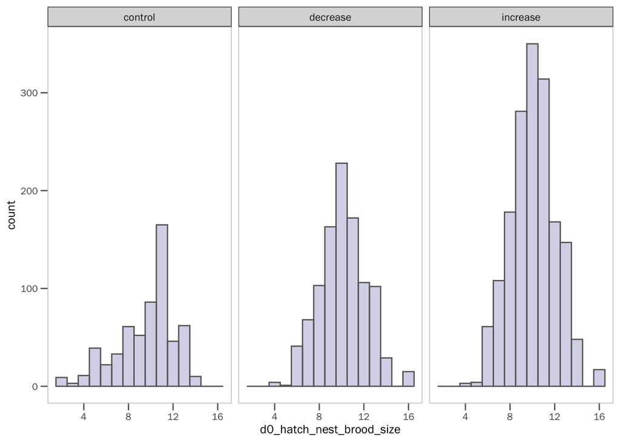

```r
BT_data_tidy %>%
  # histogram of brood size distribution across the three levels of treatment
  ggplot() +
  geom_histogram(aes(d0_hatch_nest_brood_size), alpha = 0.3, color = "grey40", fill = "#7570B3",
                 binwidth = 1, position = "identity") +
  facet_grid(. ~ rear_nest_trt)
```

plot of rear_d0_rear_nest_brood_size based on treatment

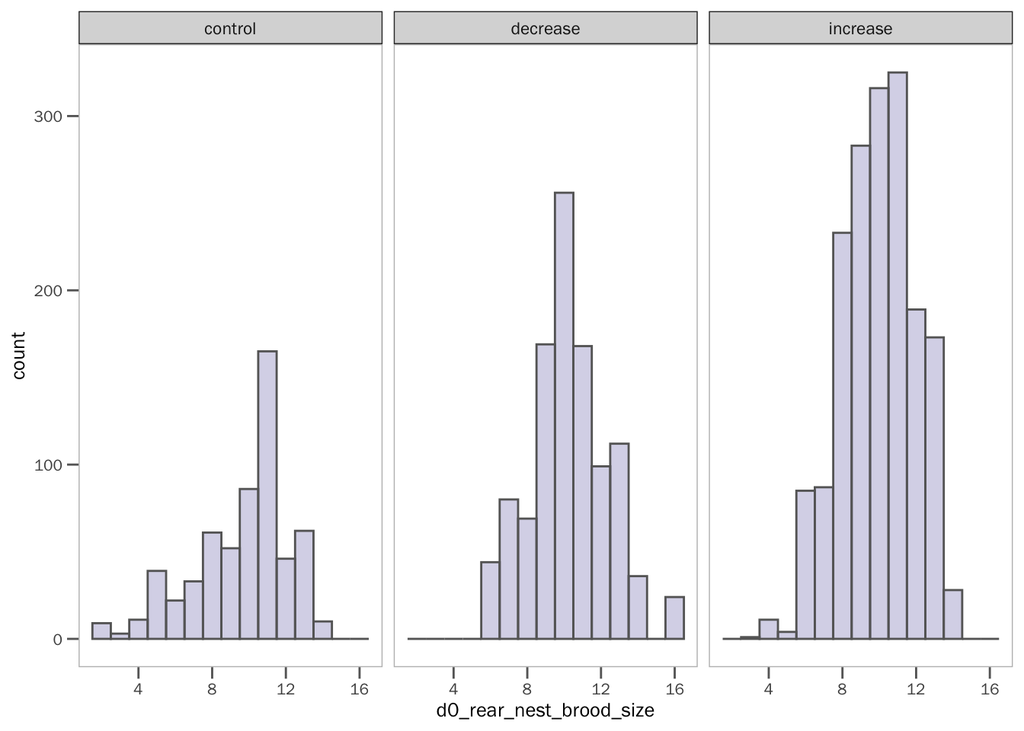

```r
BT_data_tidy %>%
  # histogram of brood size distribution across the three levels of treatment
  ggplot() +
  geom_histogram(aes(d0_rear_nest_brood_size), alpha = 0.3, color = "grey40", fill = "#7570B3",
                 binwidth = 1, position = "identity") +
  facet_grid(. ~ rear_nest_trt)
```

plot of rear_Cs_at_start_of_rearing based on treatment

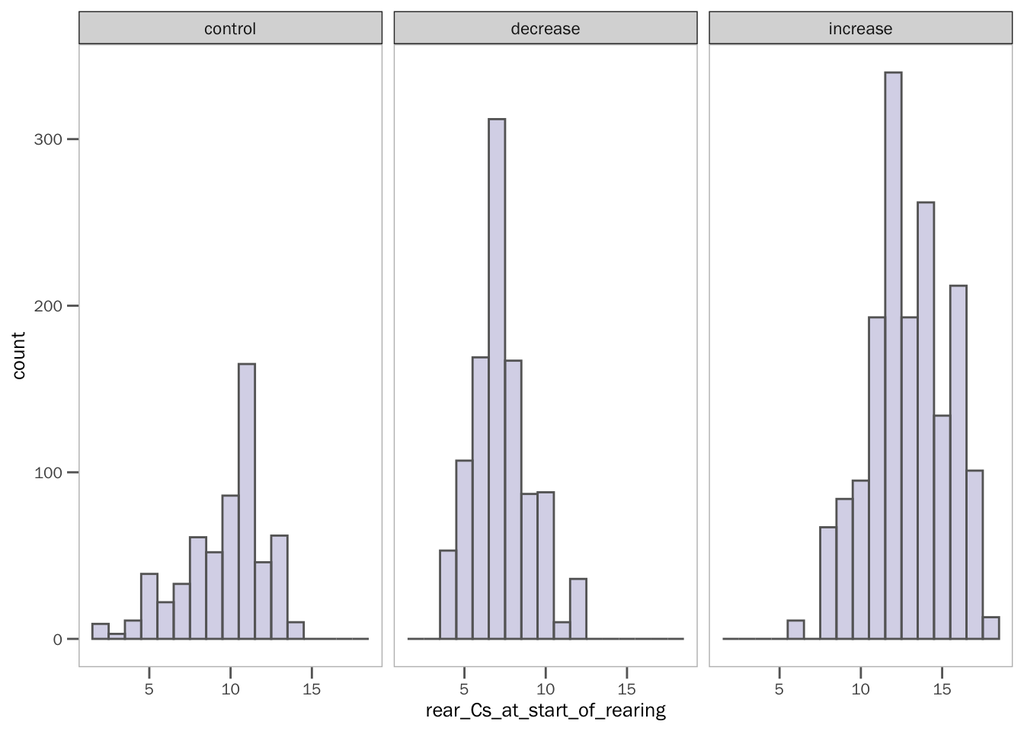

```r
BT_data_tidy %>%
  # histogram of brood size distribution across the three levels of treatment
  ggplot() +
  geom_histogram(aes(rear_Cs_at_start_of_rearing), alpha = 0.3, color = "grey40", fill = "#7570B3",
                 binwidth = 1, position = "identity") +
  facet_grid(. ~ rear_nest_trt)
```

proportional table of d0_hatch_nest_brood_size based on treatment *Increase*

```r
BT_data_tidy %>%
  count(rear_nest_trt, d0_hatch_nest_brood_size) %>%
  group_by(rear_nest_trt) %>%
  mutate(prop = prop.table(n)) %>%
  filter(rear_nest_trt == "increase") %>%
  collect() %>%
  kable() %>%
  kable_styling() %>%
  scroll_box(width = "100%")
```

| rear_nest_trt | d0_hatch_nest_brood_size | n | prop |
| --- | --- | --- | --- |
| increase | 4 | 3 | 0.0017222 |
| increase | 5 | 4 | 0.0022962 |
| increase | 6 | 61 | 0.0350172 |
| increase | 7 | 108 | 0.0619977 |
| increase | 8 | 178 | 0.1021814 |
| increase | 9 | 281 | 0.1613088 |
| increase | 10 | 350 | 0.2009185 |
| increase | 11 | 314 | 0.1802526 |
| increase | 12 | 168 | 0.0964409 |
| increase | 13 | 147 | 0.0843858 |
| increase | 14 | 48 | 0.0275545 |
| increase | 16 | 17 | 0.0097589 |
| increase | NA | 63 | 0.0361653 |

proportional table of d0_hatch_nest_brood_size based on treatment *Decrease*

```r
BT_data_tidy %>%
  count(rear_nest_trt, d0_hatch_nest_brood_size) %>%
  group_by(rear_nest_trt) %>%
  mutate(prop = prop.table(n)) %>%
  filter(rear_nest_trt == "decrease") %>%
  collect() %>%
  kable() %>%
  kable_styling() %>%
  scroll_box(width = "100%")
```

| rear_nest_trt | d0_hatch_nest_brood_size | n | prop |
| --- | --- | --- | --- |
| decrease | 4 | 4 | 0.0037771 |
| decrease | 5 | 1 | 0.0009443 |
| decrease | 6 | 41 | 0.0387158 |
| decrease | 7 | 68 | 0.0642115 |
| decrease | 8 | 103 | 0.0972616 |
| decrease | 9 | 163 | 0.1539188 |
| decrease | 10 | 228 | 0.2152975 |
| decrease | 11 | 172 | 0.1624174 |
| decrease | 12 | 106 | 0.1000944 |
| decrease | 13 | 102 | 0.0963173 |
| decrease | 14 | 29 | 0.0273843 |
| decrease | 16 | 15 | 0.0141643 |
| decrease | NA | 27 | 0.0254958 |

proportional table of d0_hatch_nest_brood_size based on treatment *Control*

```r
BT_data_tidy %>%
  count(rear_nest_trt, d0_hatch_nest_brood_size) %>%
  group_by(rear_nest_trt) %>%
  mutate(prop = prop.table(n)) %>%
  filter(rear_nest_trt == "control") %>%
  collect() %>%
  kable() %>%
  kable_styling() %>%
  scroll_box(width = "100%")
```

| rear_nest_trt | d0_hatch_nest_brood_size | n | prop |
| --- | --- | --- | --- |
| control | 2 | 9 | 0.0097933 |
| control | 3 | 3 | 0.0032644 |
| control | 4 | 11 | 0.0119695 |
| control | 5 | 39 | 0.0424374 |
| control | 6 | 22 | 0.0239391 |
| control | 7 | 33 | 0.0359086 |
| control | 8 | 61 | 0.0663765 |
| control | 9 | 52 | 0.0565832 |
| control | 10 | 86 | 0.0935800 |
| control | 11 | 165 | 0.1795430 |
| control | 12 | 46 | 0.0500544 |
| control | 13 | 62 | 0.0674646 |
| control | 14 | 10 | 0.0108814 |
| control | NA | 320 | 0.3482046 |

Following this, it seems like 8 might be a good cutoff for the two groups of brood size (i.e., d0_hatch_nest_brood_size < 8 then “small”, d0_hatch_nest_brood_size > 8 then “large”)

#### Is it true that manipulations were approximately “one-fourth” of the original brood size?

No: it seems like the manipulations were roughly “one third” (as written in the field methods). vertical dashed lines in this plot show 0.25% of the hatched nest brood size (i.e., one-fourth).

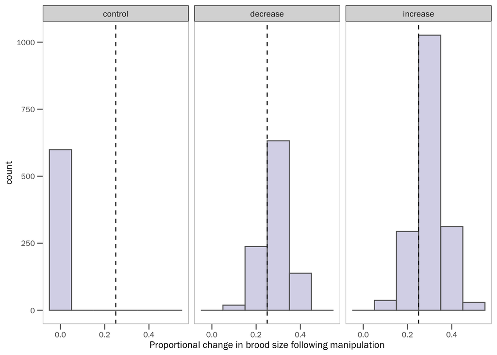

```r
# plot of proportion of brood moved based on treatment
BT_data_tidy %>%
  # create a group variable specifying if it was a small or large nest
  mutate(proportional_change_in_brood_size = abs((rear_Cs_at_start_of_rearing / d0_rear_nest_brood_size) - 1)) %>%
  ggplot() +
  geom_histogram(aes(proportional_change_in_brood_size), alpha = 0.3, color = "grey40", fill = "#7570B3",
                 binwidth = 0.1, position = "identity") +
  geom_vline(xintercept = 0.25, linetype = "dashed") +
  facet_grid(. ~ rear_nest_trt) +
  xlab("Proportional change in brood size following manipulation")
```

Summary table of proportional changes. Note that mean and median proporational changes are ~0.3 (i.e., one-third). Max change was 0.5, min change was 0.09.

```r
# table of proportion of brood moved based on treatment
BT_data_tidy %>%
  # create a group variable specifying if it was a small or large nest
  mutate(proportional_change_in_brood_size = abs((rear_Cs_at_start_of_rearing / d0_rear_nest_brood_size) - 1)) %>%
  group_by(rear_nest_trt) %>%
  # select(proportional_change_in_brood_size) %>%
  dplyr::summarise(mean_ = mean(proportional_change_in_brood_size, na.rm = TRUE),
            median_ = median(proportional_change_in_brood_size, na.rm = TRUE),
            max_ = max(proportional_change_in_brood_size, na.rm = TRUE),
            min_ = min(proportional_change_in_brood_size, na.rm = TRUE)) %>%
  mutate(across(where(is.numeric), round, 3)) %>%
  pivot_longer(-rear_nest_trt, values_to = "prop_change", names_to = "statistic") %>%
  collect() %>%
  kable() %>%
  kable_styling() %>%
  scroll_box(width = "100%")
```

| rear_nest_trt | statistic | prop_change |
| --- | --- | --- |
| control | mean_ | 0.000 |
| control | median_ | 0.000 |
| control | max_ | 0.000 |
| control | min_ | 0.000 |
| decrease | mean_ | 0.295 |
| decrease | median_ | 0.300 |
| decrease | max_ | 0.444 |
| decrease | min_ | 0.091 |
| increase | mean_ | 0.306 |
| increase | median_ | 0.308 |
| increase | max_ | 0.500 |
| increase | min_ | 0.091 |

#### How well are paired nests paired according to brood size?

plot of the difference in brood size between paired nests

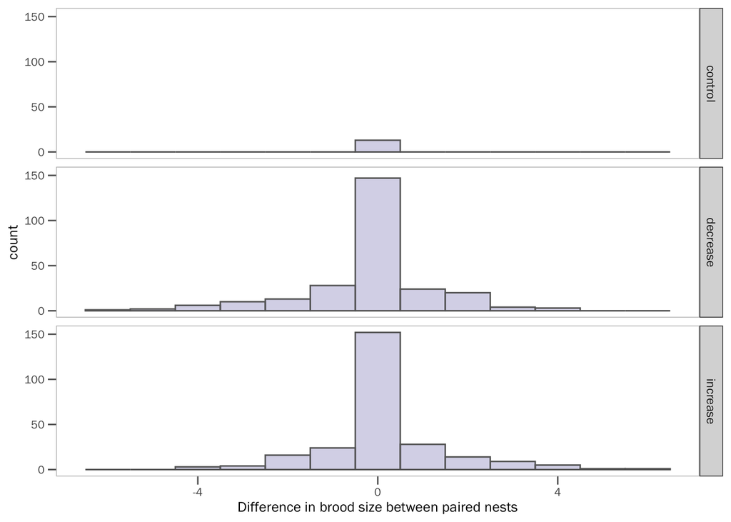

```r
BT_data_tidy %>%
  dplyr::select(pair_ID, d0_hatch_nest_brood_size, d0_rear_nest_brood_size, rear_nest_trt) %>%
  distinct() %>%
  # calculate differences in brood size between hatch and rear nests
  mutate(diff_brood_size = d0_hatch_nest_brood_size - d0_rear_nest_brood_size) %>%
  ggplot() +
  geom_histogram(aes(diff_brood_size), alpha = 0.3, color = "grey40", fill = "#7570B3",
                 binwidth = 1, position = "identity") +
  xlab("Difference in brood size between paired nests") +
  facet_grid(rear_nest_trt ~ .)
```

proportional table of differences in brood sizes (seems like ~90% of nests are matched within 3 chicks of eachother)

```r
BT_data_tidy %>%
  select(pair_ID, d0_hatch_nest_brood_size, d0_rear_nest_brood_size, rear_nest_trt) %>%
  distinct() %>%
  # calculate differences in brood size between hatch and rear nests
  mutate(paired_nest_diff_brood_size = d0_hatch_nest_brood_size - d0_rear_nest_brood_size) %>%
  count(rear_nest_trt, paired_nest_diff_brood_size) %>%
  group_by(rear_nest_trt) %>%
  mutate(prop = round(prop.table(n), 3)) %>%
  collect() %>%
  kable() %>%
  kable_styling() %>%
  scroll_box(width = "100%")
```

| rear_nest_trt | paired_nest_diff_brood_size | n | prop |
| --- | --- | --- | --- |
| control | 0 | 13 | 0.929 |
| control | NA | 1 | 0.071 |
| decrease | -6 | 1 | 0.004 |
| decrease | -5 | 2 | 0.007 |
| decrease | -4 | 6 | 0.022 |
| decrease | -3 | 10 | 0.037 |
| decrease | -2 | 13 | 0.049 |
| decrease | -1 | 28 | 0.105 |
| decrease | 0 | 147 | 0.551 |
| decrease | 1 | 24 | 0.090 |
| decrease | 2 | 20 | 0.075 |
| decrease | 3 | 4 | 0.015 |
| decrease | 4 | 3 | 0.011 |
| decrease | NA | 9 | 0.034 |
| increase | -4 | 3 | 0.011 |
| increase | -3 | 4 | 0.015 |
| increase | -2 | 16 | 0.059 |
| increase | -1 | 24 | 0.089 |
| increase | 0 | 152 | 0.563 |
| increase | 1 | 28 | 0.104 |
| increase | 2 | 14 | 0.052 |
| increase | 3 | 9 | 0.033 |
| increase | 4 | 5 | 0.019 |
| increase | 5 | 1 | 0.004 |
| increase | 6 | 1 | 0.004 |
| increase | NA | 13 | 0.048 |

#### Identify outlier pairs that differ by more than 3 chicks in thier initial size?

```r
BT_data_tidy %>%
  # calculate differences in brood size between hatch and rear nests
  mutate(paired_nest_diff_brood_size = d0_hatch_nest_brood_size - d0_rear_nest_brood_size) %>%
  filter(paired_nest_diff_brood_size < -3 | paired_nest_diff_brood_size > 3) %>%
  select(pair_ID, hatch_nest_breed_ID, d0_hatch_nest_brood_size, d0_rear_nest_brood_size, paired_nest_diff_brood_size, rear_nest_trt) %>%
  distinct() %>%
  arrange(hatch_nest_breed_ID) %>%
  collect() %>%
  kable() %>%
  kable_styling() %>%
  scroll_box(width = "100%")
```

| pair_ID | hatch_nest_breed_ID | d0_hatch_nest_brood_size | d0_rear_nest_brood_size | paired_nest_diff_brood_size | rear_nest_trt |
| --- | --- | --- | --- | --- | --- |
| 201204_201206 | 201204 | 8 | 12 | -4 | decrease |
| 201204_201206 | 201206 | 12 | 8 | 4 | increase |
| 201229_201327 | 201229 | 12 | 16 | -4 | decrease |
| 201229_201327 | 201327 | 16 | 12 | 4 | increase |
| 202016_202040 | 202016 | 11 | 7 | 4 | decrease |
| 202032_202049 | 202032 | 9 | 13 | -4 | increase |
| 202016_202040 | 202040 | 7 | 11 | -4 | increase |
| 202032_202049 | 202049 | 13 | 9 | 4 | decrease |
| 202071_202089 | 202071 | 8 | 13 | -5 | decrease |
| 202232_202241 | 202232 | 10 | 14 | -4 | decrease |
| 202232_202241 | 202241 | 14 | 10 | 4 | increase |
| 202270_202288 | 202270 | 9 | 13 | -4 | decrease |
| 202270_202288 | 202288 | 13 | 9 | 4 | increase |
| 202319_202331 | 202319 | 9 | 13 | -4 | decrease |
| 202319_202331 | 202331 | 13 | 9 | 4 | increase |
| 203067_203101 | 203067 | 12 | 6 | 6 | increase |
| 203088_203090 | 203088 | 10 | 6 | 4 | decrease |
| 203088_203090 | 203090 | 6 | 10 | -4 | increase |
| 203067_203101 | 203101 | 6 | 12 | -6 | decrease |
| 203106_203121 | 203106 | 11 | 6 | 5 | increase |
| 203106_203121 | 203121 | 6 | 11 | -5 | decrease |
| 203280_203345 | 203280 | 9 | 13 | -4 | decrease |

check for manipulated nest without a pair

```r
# function that does the opposite of "%in%"
`%!in%` = Negate(`%in%`)

# There are 3 rear_nest_breed_ID that are not in the hatch_nest_breed_ID.
# This means that there are
BT_data_tidy %>%
  filter(rear_nest_trt != "control") %>%
  filter(rear_nest_breed_ID %!in% hatch_nest_breed_ID) %>%
  select(rear_nest_breed_ID, hatch_nest_breed_ID) %>%
  distinct()

# There are 48 hatch_nest_breed_ID that are not in the rear_nest_breed_ID.
BT_data_tidy %>%
  filter(rear_nest_trt != "control") %>%
  filter(hatch_nest_breed_ID %!in% rear_nest_breed_ID) %>%
  select(rear_nest_breed_ID, hatch_nest_breed_ID) %>%
  distinct()
```

[output not shown]